# Xenium

## Introduction to spatial dataset

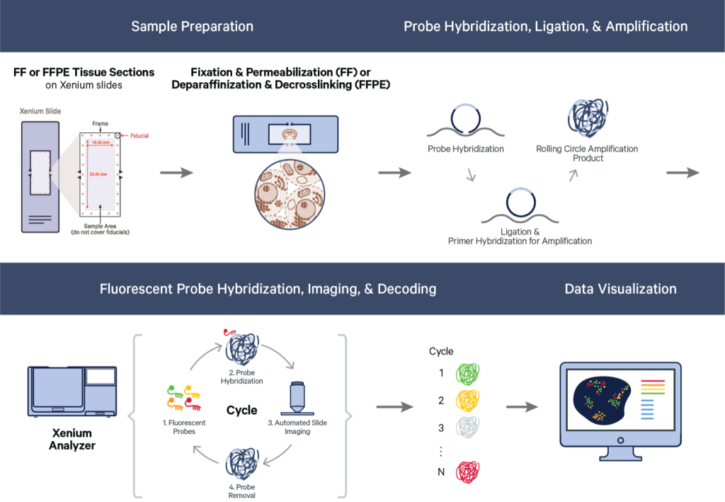

This is the 10X Xenium FFPE Human Lung Cancer dataset. Xenium captures individual transcript detections with a spatial resolution of 100s of nanometers, providing an extremely highly resolved subcellular spatial dataset. This dataset has multimodal cell segmentation outputs.

The Xenium Human Multi-Tissue and Cancer Panel (377) genes was used. The exported data is from their Xenium Onboard Analysis v2.0.0 pipeline.

The full data for this example can be found here: [here](https://www.10xgenomics.com/datasets/preview-data-ffpe-human-lung-cancer-with-xenium-multimodal-cell-segmentation-1-standard)

The relevant items are:

- Xenium Output Bundle (full)
- Supplemental: Post-Xenium H&E image (OME-TIFF)
- Supplemental: H&E Image Alignment File (CSV)

**Additional package requirements**

When working with this data and trying to open the parquet files, you will need *arrow* built with ZTSD support.

```r
has_arrow <- requireNamespace("arrow", quietly = TRUE)
zstd <- TRUE
if (has_arrow) {
    zstd <- arrow::arrow_info()$capabilities[["zstd"]]
}
if (!has_arrow || !zstd) {
    Sys.setenv(ARROW_WITH_ZSTD = "ON")
    # this may take a while
    install.packages("arrow", repos = c("https://apache.r-universe.dev"), type = "source")
}
```

### Output directory structure

```
    ├── analysis.tar.gz
    ├── analysis.zarr.zip
    ├── analysis_summary.html
    ├── aux_outputs.tar.gz
    ├── transcripts.csv.gz
    ├── transcripts.parquet
    ├── transcripts.zarr.zip
    ├── cell_boundaries.csv.gz
    ├── cell_boundaries.parquet
    ├── nucleus_boundaries.csv.gz
    ├── nucleus_boundaries.parquet
    ├── cell_feature_matrix.tar.gz
    ├── cell_feature_matrix
    │   ├── barcodes.tsv.gz
    │   ├── features.tsv.gz
    │   └── matrix.mtx.gz
    ├── cell_feature_matrix.h5
    ├── cell_feature_matrix.zarr.zip
    ├── cells.csv.gz
    ├── cells.parquet
    ├── cells.zarr.zip
    ├── experiment.xenium
    ├── gene_panel.json
    ├── metrics_summary.csv
    ├── morphology.ome.tif
    ├── morphology_focus
    │   ├── morphology_focus_0000.ome.tif
    │   ├── morphology_focus_0001.ome.tif
    │   ├── morphology_focus_0002.ome.tif
    │   ├── morphology_focus_0003.ome.tif
    ├── Xenium_V1_humanLung_Cancer_FFPE_he_image.ome.tif
    └── Xenium_V1_humanLung_Cancer_FFPE_he_imagealignment.csv
```

The above directory structuring and naming is characteristic of Xenium v2.0 pipeline outputs. The only items that may not be exactly the same across all outputs are the morphology focus directory and the naming of the aligned image items.

For the morphology focus images, you may have fewer images if the experiment did not include the multimodal cell segmentation. As for the aligned images, this is usually done after the Xenium experiment concludes and is added on using Xenium Explorer. Naming and location of the aligned image (`he_image.ome.tif`) and associated alignment info `he_imagealignment.csv` are entirely up to the user.

### Mini Xenium Dataset

In order to speed up the steps of the demo and make it locally runnable, we provide a subset of the full dataset.

```
- Full: -16.039, 12342.984, -3511.515, -294.455 (xmin, xmax, ymin, ymax)
- Mini: 6000,    7000,      -2200,     -1400    (xmin, xmax, ymin, ymax)
```

```r
library(Giotto)

# set up paths
data_path <- "data/"
save_dir <- "results/"
dir.create(save_dir, recursive = TRUE)

# download the mini dataset and untar
options("timeout" = Inf)
download.file( # 207.7MB
    url = "https://zenodo.org/records/13207308/files/workshop_xenium.zip?download=1",
    destfile = file.path(save_dir, "workshop_xenium.zip")
)
# untar the downloaded data
untar(tarfile = file.path(save_dir, "workshop_xenium.zip"),
      exdir = data_path)

# move a nonstandard file (otherwise file detection is impacted)
file.rename(
    file.path(data_path, "morphology_focus", "morphology_focus_0000.xml"),
    file.path(data_path, "morphology_focus_0000.xml")
)
```

## Convenience function

Giotto has flexible methods for working with the Xenium outputs. The `createGiottoXeniumObject()` will generate a `giotto` object in a single step when provided the output directory.

The default behavior is to load:

- transcripts information
- cell and nucleus boundaries
- feature metadata (gene_panel.json)

For the full dataset (HPC): *time: 1-2min | memory: 24GBC*

```r
?createGiottoXeniumObject

g <- createGiottoXeniumObject(xenium_dir = data_path)

# set instructions for save directory and to save the plots to disk
instructions(g, "save_dir") <- save_dir
instructions(g, "save_plot") <- TRUE
```

There are a lot of other parameters for additional or alternative items you can load. The next subsections will explain a couple of them.

### Specific filepaths

```
expression_path = ,
cell_metadata_path = ,
transcript_path = ,
bounds_path = ,
gene_panel_json_path = ,
```

The convenience function auto-detects filepaths based on the Xenium directory path and the preferred file formats

- `.parquet` for tabular (vs `.csv`)
- `.h5` for matrix over other formats when available (vs `.mtx`)
- `.zarr` is currently not supported.

When you need to use a different file format or something is not in the expected output structure, you can supply a specific filepath to the convenience function using these parameters.

### Quality value

```
qv_threshold = 20 # default
```

The *Quality Value* is a Phred-based 0-40 value that 10X provides for every detection in their transcripts output. Higher values mean higher confidence in the decoded transcript identity. By default 10X uses a cutoff of QV = 20 for transcripts to use downstream.

_*setting a value other than 20 will make the loaded dataset different from the 10X-provided expression matrix and cell metadata._

**QV Calculation**

1. Raw Q-score based on how likely it is that an observed code is to be the codeword that it gets mapped to vs less likely codeword.
2. Adjustment of raw Q-score by binning the transcripts by Q-value then adjusting the exact Q per bin based on proportion of **Negative Control Codewords** detected within.

[further info](https://www.10xgenomics.com/support/software/xenium-onboard-analysis/latest/algorithms-overview/xoa-algorithms#qvs)

### Transcript type splitting

```
feat_type =  c(
    "rna",
    "NegControlProbe",
    "UnassignedCodeword",
    "NegControlCodeword"
),
split_keyword = list(
    c("NegControlProbe"),
    c("UnassignedCodeword"),
    c("NegControlCodeword)"
)
```

There are 4 types of transcript detections that 10X reports with their v2.0 pipeline:

- **Gene expression** - This is the rna gene detections.
- **Negative Control Codeword** - (QC) Codewords that do not map to genes, but are in the codebook. Used to determine specificity of decoding algorithm.
- **Negative Control Probe** - (QC) Probes in panel but target non-biological sequences. Used to determine specificity of assay.
- **Unassigned Codeword** - (QC) Codewords that should not be used in the current panel.

With V3 on their Xenium prime outputs, there is additionally:

- **Genomic Control Codeword** (QC) Probes for intergenic genomic DNA instead of transcripts.

The main thing to watch out for is that the other probe types should be separated out from the the **Gene expression** or **rna** feature type.

How to deal with these different types of detections is easily adjustable. With the `feat_type` param you declare which categories/`feat_types` you want to split transcript detections into. Then with `split_keyword`, you provide a list of character vectors containing `grep()` terms to search for.

Note that there are 4 `feat_types` declared in this set of defaults, but 3 items passed to `split_keyword`. Any transcripts not matched by items in `split_keyword`, get categorized as the first provided `feat_type` (“rna”).

### Centroids calculation

Several Giotto operations require that a set of centroids are calculated for polygon spatial units.

```r
g <- addSpatialCentroidLocations(g, poly_info = "cell")
g <- addSpatialCentroidLocations(g, poly_info = "nucleus")
```

### Simple visualization

```r
spatInSituPlotPoints(g,
    polygon_feat_type = "cell",
    feats = list(rna = head(featIDs(g))), # must be named list
    use_overlap = FALSE,
    polygon_color = "cyan",
    polygon_line_size = 0.1
)
```

## Piecewise loading

Giotto also provides the `importXenium()` import utility that allows independent creation of compatible Giotto subobjects for more flexibility.

```r
x <- importXenium(data_path)

force(x)
```

### Load giottoPoints transcripts

```r
x$qv <- 20 # default
tx <- x$load_transcripts()
tx
```

```r
tx$rna
plot(tx$rna)
plot(tx$rna, dens = TRUE)
```

```r
rm(tx) # remove to save space
```

### (optional) Loading pre-aggregated data

Giotto can spatially aggregate the transcripts information based on a provided set of boundaries information, however 10X also provides a pre-aggregated set of cell by feature information and metadata. These values may be slightly different from those calculated by Giotto”s pipeline, and are not loaded by default.

Some care needs to be taken when loading this information:

- The `feat_type` of the loaded expression information should be matched to the used `feat_type` parameters passed to the convenience function.
- The `qv_threshold` used must be 20 since the 10X outputs are based on that cutoff.

```r
x$filetype$expression <- "mtx" # change to mtx instead of .h5 which is not in the mini dataset

ex <- x$load_expression()
featType(ex)
```

```
[1] "rna"                       "Negative Control Probe"    "Negative Control Codeword"
[4] "Unassigned Codeword"
```

The feature types here do not match what we established for the transcripts, so we can just change them.

Another reason for changing them here is just because the default names have ’ ’ characters which are difficult to work with.

```r
force(g)
```

```
An object of class giotto
>Active spat_unit:  cell
>Active feat_type:  rna
[SUBCELLULAR INFO]
polygons      : cell nucleus
features      : rna NegControlProbe UnassignedCodeword NegControlCodeword
[AGGREGATE INFO]
spatial locations ----------------
[cell] raw
[nucleus] raw
```

```r
featType(ex[[2]]) <- c("NegControlProbe")
featType(ex[[3]]) <- c("NegControlCodeword")
featType(ex[[4]]) <- c("UnassignedCodeword")
```

Then we can just append them to the Giotto object.

Here we set up a second object called `g2` since we will be using Giotto’s own aggregation method to generate the expression matrix later.

```r
g2 <- g
# append the expression info
g2 <- setGiotto(g2, ex)

# load cell metadata
cx <- x$load_cellmeta()
g2 <- setGiotto(g2, cx)

force(g2)
```

```
An object of class giotto
>Active spat_unit:  cell
>Active feat_type:  rna
[SUBCELLULAR INFO]
polygons      : cell nucleus
features      : rna NegControlProbe UnassignedCodeword NegControlCodeword
[AGGREGATE INFO]
expression -----------------------
[cell][rna] raw
[cell][NegControlProbe] raw
[cell][NegControlCodeword] raw
[cell][UnassignedCodeword] raw
spatial locations ----------------
[cell] raw
[nucleus] raw
```

```r
spatInSituPlotPoints(g2,
    # polygon shading params
    polygon_fill = "cell_area",
    polygon_fill_as_factor = FALSE,
    polygon_fill_gradient_style = "sequential",
    # polygon line params
    polygon_color = "grey",
    polygon_line_size = 0.1
)

spatInSituPlotPoints(g2,
    # polygon shading params
    polygon_fill = "transcript_counts",
    polygon_fill_as_factor = FALSE,
    polygon_fill_gradient_style = "sequential",
    # polygon line params
    polygon_color = "grey",
    polygon_line_size = 0.1
)
```

```r
rm(g2) # save space
```

## Xenium Images

Xenium outputs have several image outputs. For this dataset:

- `morphology.ome.tif` is a z-stacked image of the DAPI staining, with z levels separated as pages within the `ome.tif`. In this dataset, only pages 6 and 7 are really in focus.
- `morphology_focus` is a folder containing single-channel image(s), but with the original z information collapsed into a single in-focus layer. For all datasets, image 0000 will be DAPI staining, but if you have additional stains, such as the multimodal segmentation, they will also be here. These are the recommended immunofluorescence staining images to import.
- `Xenium_V1_humanLung_Cancer_FFPE_he_image.ome.tif` is an added on (in this case H&E) image with manual affine registration.

### Image metadata

The `morphology_focus` directory may contain multiple images, but to know more information, we have to check the `ome.tif` `xml` metadata. With a normal dataset, you can use:

```
`GiottoClass::ometif_metadata([filepath], node = "Channel")`
```

on one of the `morphology_focus` images, but since the mini dataset images are pre-processed, there is only an exported `.xml` to explore. The output of the code chunk below is the same as that from calling `ometif_metadata()` and looking for the `Channel` node.

```r
img_xml_path <- file.path(data_path, "morphology_focus_0000.xml")
omemeta <- xml2::read_xml(img_xml_path)
res <- xml2::xml_find_all(omemeta, "//d1:Channel", ns = xml2::xml_ns(omemeta))
res <- Reduce(rbind, xml2::xml_attrs(res))
rownames(res) <- NULL
res <- as.data.frame(res)
force(res)
```

[output not shown]

### Image loading

`morphology_focus` images need to be scaled by the micron scaling factor. Aligned images need to first be affine transformed then scaled. The micron scaling factor can be found in the json-like `experiment.xenium` file under `pixel_size` (0.2125 for this dataset).

These transforms are normally done automatically when using:

```
# convenience function params
load_images = list(
    img1 = "[img_path1.tif]",
    img2 = "[img_path2.tif]",
    img3 = "..."
),
load_aligned_images = list(
    aligned_img = c(
        "[path to image.tif]",
        "[path to magealignment.csv]"
    )
)

# importer params
x$load_image(path = "[img_path1.tif]", name = "img1")
x$load_image(path = "[img_path2.tif]", name = "img2")
...
x$load_aligned_image(
    path = "[path to image.tif]",
    imagealignment_path = "[path to magealignment.csv]",
    name = "aligned_img"
)
```

Specifically for the aligned image, there is also `read10xAffineImage()` which has similar parameters, but also asks for the micron scaling factor.

But for the mini dataset, the images are pre-processed and can be directly added.

```r
img_paths <- c(
    sprintf("data/morphology_focus/morphology_focus_%04d.tif", 0:3),
    "data/he_mini.tif"
)

img_list <- createGiottoLargeImageList(
    img_paths,
    # naming is based on the channel metadata above
    names = c("DAPI", "18S", "ATP1A1/CD45/E-Cadherin", "alphaSMA/Vimentin", "HE"),
    use_rast_ext = TRUE,
    verbose = FALSE
)

# make some images brighter
img_list[[1]]@max_window <- 5000
img_list[[2]]@max_window <- 5000
img_list[[3]]@max_window <- 5000

# append images to gobject
g <- setGiotto(g, img_list)
```

```r
# example plots
spatInSituPlotPoints(g,
    show_image = TRUE,
    image_name = "HE",
    polygon_feat_type = "cell",
    polygon_color = "cyan",
    polygon_line_size = 0.1,
    polygon_alpha = 0
)
```

```r
spatInSituPlotPoints(g,
    show_image = TRUE,
    image_name = "DAPI",
    polygon_feat_type = "nucleus",
    polygon_color = "cyan",
    polygon_line_size = 0.1,
    polygon_alpha = 0
)
```

```r
spatInSituPlotPoints(g,
    show_image = TRUE,
    image_name = "18S",
    polygon_feat_type = "cell",
    polygon_color = "cyan",
    polygon_line_size = 0.1,
    polygon_alpha = 0
)
```

```r
spatInSituPlotPoints(g,
    show_image = TRUE,
    image_name = "ATP1A1/CD45/E-Cadherin",
    polygon_feat_type = "nucleus",
    polygon_color = "cyan",
    polygon_line_size = 0.1,
    polygon_alpha = 0
)
```

## Spatial aggregation

First calculate the `feat_info` “rna” transcripts overlapped by the `spatial_info` “cell” polygons with `calculateOverlap()`. Then, the overlaps information (relationships between points and polygons that overlap them) gets converted into a count matrix with `overlapToMatrix()`.

```r
g <- calculateOverlap(g,
    spatial_info = "cell",
    feat_info = "rna"
)

g <- overlapToMatrix(g)
```

## Aggregate analyses workflow

### Transcripts per cell

```r
g <- addStatistics(g) # this is going to fail because it looks for normalized

g <- addStatistics(g, expression_values = "raw")
```

```r
cell_stats <- pDataDT(g)
ggplot2::ggplot(cell_stats, ggplot2::aes(total_expr)) +
    ggplot2::geom_histogram(binwidth = 5)
```

### Filtering

```r
# very permissive filtering. Mainly for removing 0 values
g <- filterGiotto(g,
    expression_threshold = 1,
    feat_det_in_min_cells = 1,
    min_det_feats_per_cell = 5
)
```

```
Feature type:  rna
Number of cells removed:  143  out of  7655
Number of feats removed:  0  out of  377
```

### Normalization

```r
g <- normalizeGiotto(g)
# overwrite original results with those for normalized values
g <- addStatistics(g)
```

```r
spatInSituPlotPoints(g,
    polygon_fill = "nr_feats",
    polygon_fill_gradient_style = "sequential",
    polygon_fill_as_factor = FALSE
)
```

```r
spatInSituPlotPoints(g,
    polygon_fill = "total_expr",
    polygon_fill_gradient_style = "sequential",
    polygon_fill_as_factor = FALSE
)
```

When there are a lot of features, we would also select only the interesting highly variable features so that downstream dimension reduction has more meaningful separation. Here we skip HVF detection since there are only 377 genes.

### Dimension Reduction

Dimensional reduction of expression space to visualize expressional differences between cells and help with clustering.

```r
g <- runPCA(g, feats_to_use = NULL)
# feats_to_use = NULL since there are no HVFs calculated. Use all genes.

screePlot(g, ncp = 30)
```

```r
g <- runUMAP(g,
    dimensions_to_use = seq(15),
    n_neighbors = 40 # default
)
```

```r
plotPCA(g)
```

```r
plotUMAP(g)
```

### Clustering

```r
g <- createNearestNetwork(g,
    dimensions_to_use = seq(15),
    k = 40
)

# takes roughly 1 min to run
g <- doLeidenClusterIgraph(g)
```

```r
plotPCA_3D(g,
    cell_color = "leiden_clus",
    point_size = 1
)
```

```r
plotUMAP(g,
    cell_color = "leiden_clus",
    point_size = 0.1,
    point_shape = "no_border"
)
```

```r
spatInSituPlotPoints(g,
    polygon_fill = "leiden_clus",
    polygon_fill_as_factor = TRUE,
    polygon_alpha = 1,
    show_image = TRUE,
    image_name = "HE"
)
```

## Niche clustering

Building on top of these leiden annotations, we can define spatial niche signatures based on which leiden types are often found together.

### Spatial network

First a spatial network must be generated so that spatial relationships between cells can be understood.

```r
g <- createSpatialNetwork(g,
    method = "Delaunay"
)

spatPlot2D(g,
    point_shape = "no_border",
    show_network = TRUE,
    point_size = 0.1,
    point_alpha = 0.5,
    network_color = "grey"
)
```

### Niche calculation

Calculate a proportion table for a cell metadata table for all the spatial neighbors of each cell. This means that with each cell established as the center of its local niche, the enrichment of each leiden cluster label is found for that local niche. The results are stored as a new spatial enrichment entry called “leiden_niche”

```r
g <- calculateLabelProportions(g,
    group_method = "spatialnetwork",
    spatial_network_name = "Delaunay_network",
    labels = "leiden_clus",
    name = "leiden_niche",
    output = "gobject"
)
```

### k-means clustering based on niche signature

```r
?Giotto::clusterData
?bluster::KmeansParam
knn_param <- clusterParam("kmeans", centers = 7, iter.max = 1000, nstart = 100)
g <- clusterData(g, knn_param,
    what = "spatial_enrichment",
    spat_enr_name = "leiden_niche",
    name = "niche",
    output = "gobject"
)


# visualize niches
spatInSituPlotPoints(g,
    show_image = TRUE,
    image_name = "HE",
    polygon_fill = "niche",
    polygon_alpha = 1,
    polygon_fill_as_factor = TRUE
)
```

NA are those cells that are not assigned a niche since their spatial network connections are too sparse

```r
# visualize niche makeup
cellmeta <- pDataDT(g)

ggplot2::ggplot(
  cellmeta, ggplot2::aes(fill = as.character(leiden_clus),
                         y = 1,
                         x = as.character(niche))) +
  ggplot2::geom_bar(position = "fill", stat = "identity") +
  ggplot2::scale_fill_manual(values = c(
    "#E7298A", "#FFED6F", "#80B1D3", "#E41A1C", "#377EB8", "#A65628",
    "#4DAF4A", "#D9D9D9", "#FF7F00", "#BC80BD", "#666666", "#B3DE69")
  )
```

## Cell proximity enrichment

Using a spatial network, determine if there is an enrichment or depletion between annotation types by calculating the observed over the expected frequency of interactions.

```r
# uses a lot of memory
leiden_prox <- cellProximityEnrichment(g,
    cluster_column = "leiden_clus",
    spatial_network_name = "Delaunay_network",
    adjust_method = "fdr",
    number_of_simulations = 2000
)

cellProximityBarplot(g,
    CPscore = leiden_prox,
    min_orig_ints = 5, # minimum original cell-cell interactions
    min_sim_ints = 5 # minimum simulated cell-cell interactions
)
```

```r
# set up colors
other_cell_color <- rep("grey", 12)
int_6_8 <- int_2_9 <- other_cell_color
int_6_8[c(6, 8)] <- c("orange", "cornflowerblue")
int_2_9[c(2, 9)] <- c("orange", "cornflowerblue")
```

```r
spatInSituPlotPoints(g,
    polygon_fill = "leiden_clus",
    polygon_fill_as_factor = TRUE,
    polygon_fill_code = int_6_8,
    polygon_line_size = 0.1,
    polygon_alpha = 1,
    show_image = TRUE,
    image_name = "HE"
)
```

```r
spatInSituPlotPoints(g,
    polygon_fill = "leiden_clus",
    polygon_fill_as_factor = TRUE,
    polygon_fill_code = int_2_9,
    polygon_line_size = 0.1,
    show_image = TRUE,
    polygon_alpha = 1,
    image_name = "HE"
)
```

## Pseudovisium

Another thing we can do is create a “pseudovisium” dataset by tessellating across this dataset using the same layout and resolution as a Visium capture array.

`makePseudoVisium()` generates a Visium array of circular polygons across the spatial extent provided.

Here we use `ext()` with the `prefer` arg pointing to the polygon and points data and `all_data = TRUE`, meaning that the combined spatial extent of those two data types will be returned, giving a good measure of where all the data in the object is at the moment.

`micron_size = 1` since the Xenium data is already scaled to microns.

```r
pvis <- makePseudoVisium(
    extent = ext(g, prefer = c("polygon", "points"), all_data = TRUE),
     # all_data = TRUE is the default
    micron_size = 1
)

g <- setGiotto(g, pvis)
g <- addSpatialCentroidLocations(g, poly_info = "pseudo_visium")

plot(pvis)
```

### Pseudovisium aggregation and workflow

Make “pseudo_visium” the new default spatial unit then proceed with aggregation and usual aggregate workflow.

```r
activeSpatUnit(g) <- "pseudo_visium"

g <- calculateOverlap(g,
    spatial_info = "pseudo_visium",
    feat_info = "rna"
)

g <- overlapToMatrix(g)

g <- filterGiotto(g,
    expression_threshold = 1,
    feat_det_in_min_cells = 1,
    min_det_feats_per_cell = 100
)

g <- normalizeGiotto(g)

g <- addStatistics(g)

spatInSituPlotPoints(g,
    show_image = TRUE,
    image_name = "HE",
    polygon_feat_type = "pseudo_visium",
    polygon_fill = "total_expr",
    polygon_fill_gradient_style = "sequential"
)
```

```r
g <- runPCA(g, feats_to_use = NULL)

g <- runUMAP(g,
    dimensions_to_use = seq(15),
    n_neighbors = 15
)

g <- createNearestNetwork(g,
    dimensions_to_use = seq(15),
    k = 15
)

g <- doLeidenCluster(g, resolution = 1.5)
```

```r
# plots
plotPCA(g,
    cell_color = "leiden_clus",
    point_size = 2)
```

```r
plotUMAP(g,
    cell_color = "leiden_clus",
    point_size = 2)
```

```r
spatInSituPlotPoints(g,
    polygon_feat_type = "pseudo_visium",
    polygon_fill = "leiden_clus",
    polygon_fill_as_factor = TRUE
)
```

```r
spatInSituPlotPoints(g,
    polygon_feat_type = "pseudo_visium",
    polygon_fill = "leiden_clus",
    polygon_fill_as_factor = TRUE,
    show_image = TRUE,
    image_name = "HE"
)
```